# 1. Import the necessary libraries

```python
import numpy as np
import pandas as pd
import matplotlib.pyplot as mpt
import seaborn as sns
from scipy.stats import ttest_ind
from statsmodels.stats.proportion import proportions_ztest
import statsmodels.api         as     sm
from   statsmodels.formula.api import ols
```

# 2. Read the data as a data frame

```python
insu = pd.read_csv('insurance.csv')
```

# 3. Perform basic EDA which should include the following and print out your insights at every step.

# a. Shape of the data

```python
insu.shape
```

```
(1338, 7)
```

#### This dataframe has 1338 data rows and 7 data columns

# b. Data type of each attribute

```python
insu.info()
```

```
<class 'pandas.core.frame.DataFrame'>
RangeIndex: 1338 entries, 0 to 1337
Data columns (total 7 columns):
age         1338 non-null int64
sex         1338 non-null object
bmi         1338 non-null float64
children    1338 non-null int64
smoker      1338 non-null object
region      1338 non-null object
charges     1338 non-null float64
dtypes: float64(2), int64(2), object(3)
memory usage: 73.3+ KB
```

#### Attributes bmi and charges are floating numbers representing continous variables. Attributes age and children are integer numbers representing discrete variables. Attributes sex, smoker and region are text values representing categorical variables.

# c. Checking the presence of missing values

```python
insu.isnull().sum()
```

```
age         0
sex         0
bmi         0
children    0
smoker      0
region      0
charges     0
dtype: int64
```

#### There are no missing values for any of the attributes.

# d. 5 point summary of numerical attributes

```python
insu.describe()
```

|  | age | bmi | children | charges |
| --- | --- | --- | --- | --- |
| count | 1338.000000 | 1338.000000 | 1338.000000 | 1338.000000 |
| mean | 39.207025 | 30.663397 | 1.094918 | 13270.422265 |
| std | 14.049960 | 6.098187 | 1.205493 | 12110.011237 |
| min | 18.000000 | 15.960000 | 0.000000 | 1121.873900 |
| 25% | 27.000000 | 26.296250 | 0.000000 | 4740.287150 |
| 50% | 39.000000 | 30.400000 | 1.000000 | 9382.033000 |
| 75% | 51.000000 | 34.693750 | 2.000000 | 16639.912515 |
| max | 64.000000 | 53.130000 | 5.000000 | 63770.428010 |

#### 5 point summary is measured for all discrete and continous variables - in this case age, bmi, children and charges. 5 point summary parameters include Mean, Lower Value (min), Upper Value (max), Q1 (25%) and Q3 (75%) age varies from 18 to 64, with a mean of 39.20, Q1 of 27 and Q3 of 51, bmi varies from 15.96 to 53.13, with a mean of 30.66, Q1 of 26.29 and Q3 of 34.69, children varies from 0 to 5, with a mean of 1.09, Q1 of 0 and Q3 of 2 charges varies from 1121.87 to 63770.42, with a mean of 13270.42, Q1 of 4740.28 and Q3 of 16639.91.

# e. Distribution of ‘bmi’, ‘age’ and ‘charges’ columns

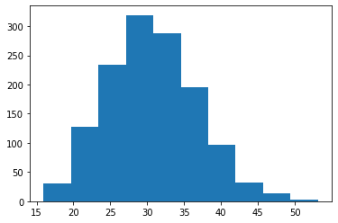

```python
#Distribution of ‘bmi’
mpt.hist(insu.bmi)
```

#### The bmi distribution shows the maximum of 319 occurances of bmi between 27.111 and 30.828

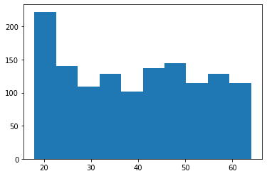

```python
#Distribution of 'age’
mpt.hist(insu.age)
```

#### The age distribution shows the maximum of 222 occurances of age between 18 and 22.6

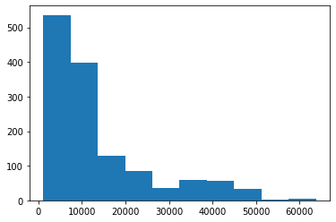

```python
#Distribution of ‘charges’
mpt.hist(insu.charges)
```

#### The charges distribution shows the maximum of 536 occurances of charges between 1121.8739 and 7386.7293

# f. Measure of skewness of ‘bmi’, ‘age’ and ‘charges’ columns

```python
#Measure of skewness of ‘bmi’
insu.bmi.skew()
```

```
0.2840471105987448
```

#### Right Skew, the mean is greater than its median

```python
#Measure of skewness of ‘age’
insu.age.skew()
```

```
0.05567251565299186
```

#### Right Skew, the mean is greater than its median

```python
#Measure of skewness of ‘charges’
insu.charges.skew()
```

```
1.5158796580240388
```

#### Right Skew, the mean is greater than its median

# g. Checking the presence of outliers in ‘bmi’, ‘age’ and ‘charges columns

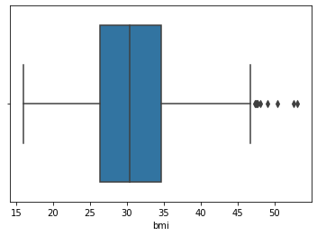

```python
#Checking the presence of outliers in ‘bmi’
sns.boxplot(x='bmi',data=insu)
```

#### The box plot indicates outliers for bmi above 47

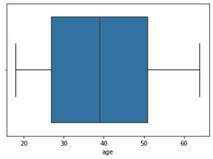

```python
#Checking the presence of outliers in ‘age’
sns.boxplot(x='age',data=insu)
```

#### The box plot does not indicate any outliers for age

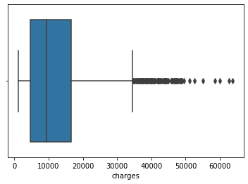

```python
#Checking the presence of outliers in ‘charges’
sns.boxplot(x='charges',data=insu)
```

#### The box plot indicates outliers for charges above 33000

# h. Distribution of categorical columns (include children)

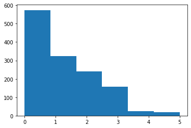

```python
#Distribution of children
mpt.hist(insu.children, bins = 6)
```

#### The distribution for children indicates the following: 574 occurances with no child, 324 occurances with 1 child, 240 occurances with 2 children, 157 occurances with 3 children, 25 occurances with 4 children, 18 occurances with 5 children.

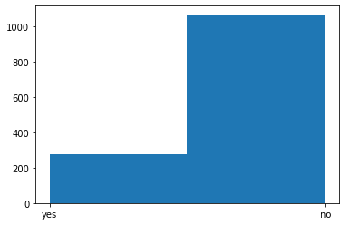

```python
#Distribution of smokers
mpt.hist(insu.smoker, bins = 2)
```

#### The distribution for smokers indicates 274 smokers and 1064 non-smokers.

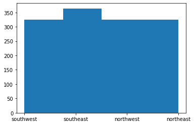

```python
#Distribution of region
mpt.hist(insu.region, bins = 4)
```

#### The region distribution shows 364 from souteast, 325 each from southwest and northwest & 324 from northeast.

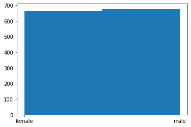

```python
#Distribution of sex
mpt.hist(insu.sex, bins = 2)
```

#### The sex distribution shows 662 females and 676 males.

# i. Pair plot that includes all the columns of the data frame

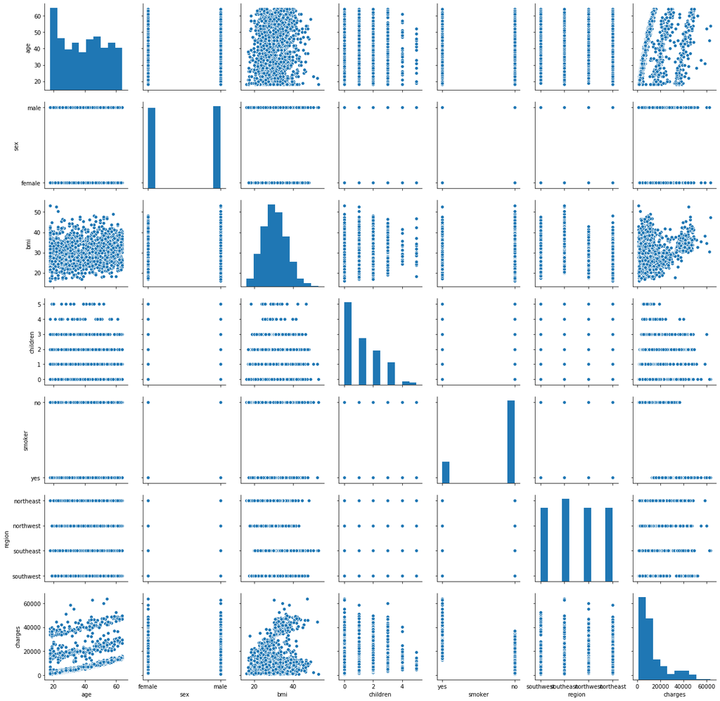

```python
sns.pairplot(insu, vars=["age","sex","bmi","children","smoker","region","charges"])
```

#### The Pair plot shows relationship between 2 variables. The diagonal shows the respective variables histogram while the others show scatter plot between 2 variables. For example, consider row 1 and column 3. This is a scatter plot between age and bmi. The plot shows equal distribution of bmi irrespective of age.

# 4. Answer the following questions with statistical evidence

# a. Do charges of people who smoke differ significantly from the people who don't?

### Lets first formulate the Hypothesis.

### Ho = Charges is same for smokers and non-smokers.

### Ha = Charges is not same for smokers and non-smokers.

#### Lets now bifurcate the data into 2 groups.

```python
smokers_charges = insu[insu['smoker'] == 'yes'].charges
non_smokers_charges = insu[insu['smoker'] == 'no'].charges
```

#### Lets now do a Two Sample T-Test for this data and assume a p-value of 0.05. We will reject the null hypothesis if the calculated p-value is less than 0.05.

```python
t_stat, p_value = ttest_ind(smokers_charges, non_smokers_charges)
print(t_stat, p_value)
```

```
46.664921172723716 8.271435842177219e-283
```

### Since p-value calculated is less than 0.05, we will reject the null hypothesis. In other words - there is definitely a difference of charges for smokers compared to non-smokers

# b. Does bmi of males differ significantly from that of females?

### Lets first formulate the Hypothesis.

### Ho = BMI is same for males and females.

### Ha = BMI is not same for males and females.

#### Lets now bifurcate the data into 2 groups.

```python
bmi_males = insu[insu['sex'] == 'male'].bmi
bmi_females = insu[insu['sex'] == 'female'].bmi
```

#### Lets now do a Two Sample T-Test for this data and assume a p-value of 0.05. We will reject the null hypothesis if the calculated p-value is less than 0.05.

```python
t_stat, p_value = ttest_ind(bmi_males, bmi_females)
print(t_stat, p_value)
```

```
1.696752635752224 0.08997637178984932
```

### Since p-value calculated is not less than 0.05, we fail to reject the null hypothesis. In other words - the bmi does not differ for males and females.

# c. Is the proportion of smokers significantly different in different genders?

### Lets first formulate the Hypothesis.

### Ho = The propotion of smokers are same for both genders.

### Ha = The propotion of smokers are not same for both genders.

#### Lets now find the propotions.

```python
# Number of Female Smokers
female_smokers = insu[insu['sex'] == 'female'].smoker.value_counts()[1]

# Total Number of Females
females = insu.sex.value_counts()[1]

# Number of Male Smokers
male_smokers = insu[insu['sex'] == 'male'].smoker.value_counts()[1]

# Total Number of Males
males = insu.sex.value_counts()[0]
```

```python
print(f'Propotion of male smokers = {male_smokers / males}% ')
print(f'Propotion of female smokers = {female_smokers / females}% ')
```

```
Propotion of male smokers = 0.23520710059171598%
Propotion of female smokers = 0.17371601208459214%
```

#### Lets now do a z_Test of propotion to see if this is staistically significant.

#### We are assuming a confidence level of 95% in this case. So if the p-value calculated is less then 0.05, we will have to reject the null hypothesis. Else, we will fail to reject it.

```python
zstat, pval = proportions_ztest([female_smokers, male_smokers] , [females, males])
print(pval)
```

```
0.005324114164320532
```

#### Since p-value calculated is less than 0.05, we will reject the null hypothesis.

### In other words - there is definitely a difference of propotion of smokers between genders.

# d. Is the distribution of bmi across women with no children, one child and two children, the same?

### Lets first formulate the Hypothesis.

### Ho = The distribution of bmi is same for woman with no children, one child and two child. In other words, the population mean of bmi is same for all 3 groups.

### Ha = The distribution of bmi is not same for woman with no children, one child and two child. In other words, the population mean of bmi is differnt for at least one pair of groups.

#### We will be using Anova Test as this is test of means of 3 samples

#### First, lets first create a dataframe of the required sample.

#### In other words, dataframe should have columns bmi, sex(only female) and children (0,1 or 2)

```python
df_3_col = insu[['bmi','sex','children']]
df_only_female = df_3_col[df_3_col['sex'] == 'female']
df_female_0_children = df_only_female[df_only_female['children'] == 0]
df_female_1_children = df_only_female[df_only_female['children'] == 1]
df_female_2_children = df_only_female[df_only_female['children'] == 2]

df_female_sample = pd.DataFrame()

df_female_sample = df_female_sample.append(df_female_0_children)
df_female_sample = df_female_sample.append(df_female_1_children)
df_female_sample = df_female_sample.append(df_female_2_children)

print(df_female_sample)
```

```
         bmi     sex  children
0     27.900  female         0
5     25.740  female         0
9     25.840  female         0
11    26.290  female         0
13    39.820  female         0
...      ...     ...       ...
1313  34.700  female         2
1319  26.315  female         2
1323  40.370  female         2
1328  24.225  female         2
1330  25.740  female         2

[566 rows x 3 columns]
```

#### Now, lets create the Anova Table

#### Lets consider a confidence leve of 95%. In that case, if p-value calculated is less than 0.05, then we will reject the null hypothesis

```python
mod = ols('bmi ~ children', data = df_female_sample).fit()
aov_table = sm.stats.anova_lm(mod, typ=2)
print(aov_table)
```

```
                sum_sq     df         F   PR(>F)
children      2.512982    1.0  0.068411  0.79376
Residual  20717.738725  564.0       NaN      NaN
```

### Since the p-value calculated is 0.79376, we fail to reject the null hypothesis.

### In other words, the bmi for woman with no children, 1 child and 2 children are the same